# Group 5 Analysis - Obesity Prevalence

# 1 Introduction

Obesity levels across Scotland are monitored as part of the Scottish Health Surveys. Within these surveys there is information on socio-economic and lifestyle factors and their effect on the prevalence of obesity in Scotland. Using data gathered between 2013 and 2016, this report will look at whether or not the prevalence of obesity has changed over this time period. In addition looking at whether there are differences in obesity prevalence caused by age, sex and socio-economic status.

Section 2 shows the exploratory analysis of Scottish Health Survey data, and explores how the prevalence of obesity in Scotland changes over years, and whether obesity prevalence differs by age, gender and employment factors. Section 3 contains the results of the fitted logistic regression models of Scottish Health Survey data, and analysis for such models based on the questions of interest. Then, we make the overall conclusion in Section 4.

# 2 Exploratory Analysis

We begin with creating a new binary response variable based on the BMIgroup variable for obesity classification, which is divided into “Obesity” and “Not Obesity”. Then, we draw a barplot Figure 1 to show how the prevalence of obesity in Scotland changes over years. Here we can see that both obesity and non-obesity barely changed between 2013 and 2016. The proportion of obesity was the highest in 2015 and the lowest in 2014, but the difference was not significant, with only a 0.4% fluctuation.

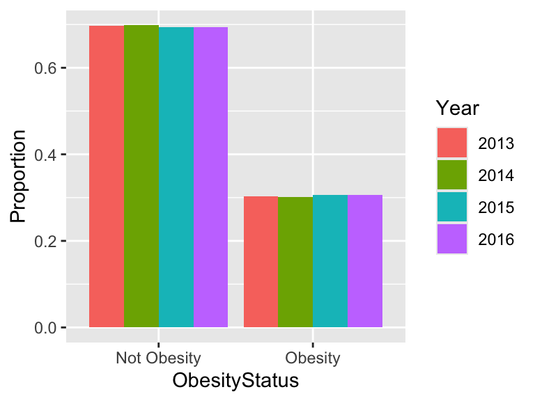

Figure 1: Barplot of Obesity by Year

To further explore whether the prevalence of obesity differs by age, gender, and employment factors, we draw different barplots on obesity by age group, sex, and employment, respectively. Figure 2 displays the proportion of obesity in different age groups. The 16-24 age group has the lowest obesity proportion, while the 65-74 age group has the highest proportion. We can see that the proportion of obesity gradually increases from the 16-24 age group to the 65-74 age group, but the obesity prevalence among the elderly over 75 years old group is lower than that in the previous age group.

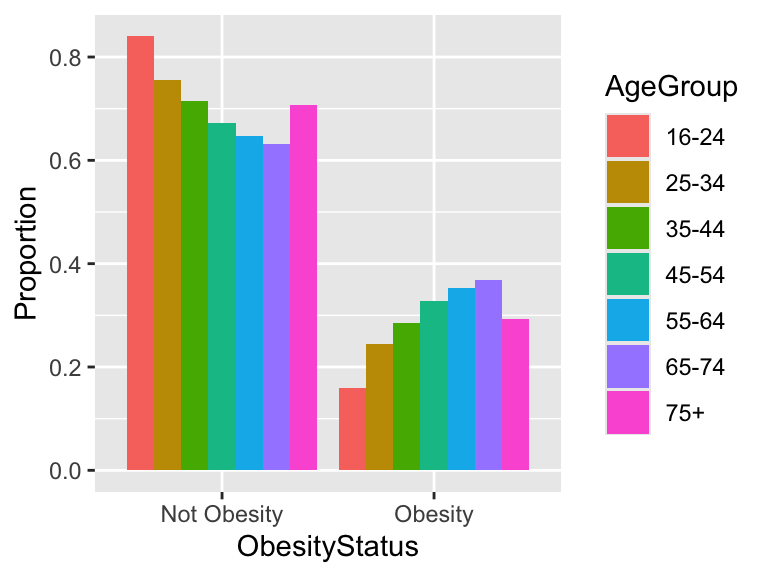

Figure 2: Barplot of Obesity by AgeGroup

Figure 3 illustrates the obesity proportion in female and male, respectively. There appears to be some difference in obesity prevalence, with female having slightly higher proportion than male.

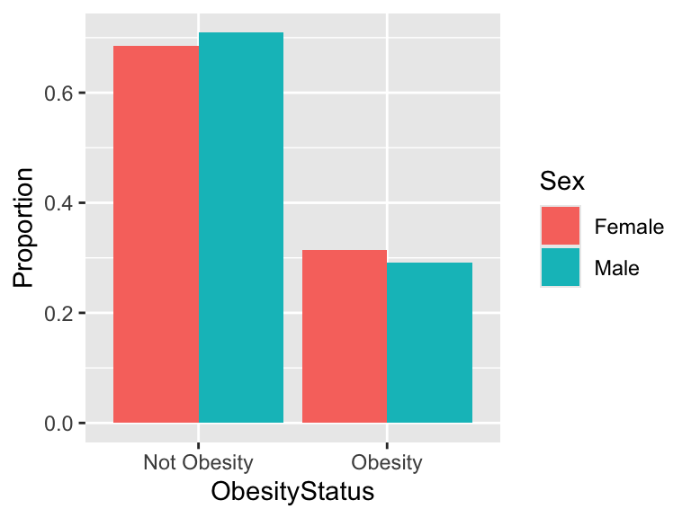

Figure 3: Barplot of Obesity by Sex

Figure 4 displays that people with full-time education have the lowest prevalence of obesity, while people who are permanently unable to work have the highest proportion. It seems likely that employment increases the prevalence of obesity, but a person is more likely to be obese if they are permanently unable to find a job.

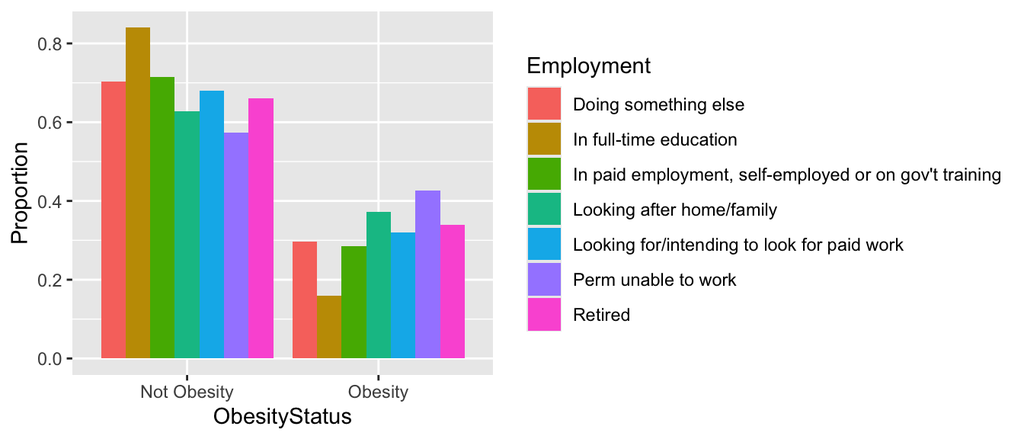

Figure 4: Barplot of Obesity by Employment

# 3 Formal Analysis

We fit the logistic regression model for obesity prevalence from 2013 to 2016,

$$\mbox{ln}(\frac{p}{1-p}) = \alpha + \beta_{\mbox{Year}} \cdot \mathbb{I}_{\mbox{Year}}(x)$$

where

- $p$ is the probability of obesity
- $1-p$ is the probability of not obesity
- $\alpha$ is the intercept of the regression line for the baseline Year (2013)
- $\beta_{\mbox{Year}}$ the additional term added to $\alpha$ to get the intercept of the regression line for the specified Year
- $\mathbb{I}_{\mbox{Year}}(x)$ is an indicator function indicating the chosen Year.

Table 1: Estimates of the intercept and slope from the fitted logistic regression model

| term | estimate | std.error | p.value |
| --- | --- | --- | --- |
| (Intercept) | −0.8330 | 0.0358 | 0.0000 |
| Year2014 | −0.0056 | 0.0513 | 0.9125 |
| Year2015 | 0.0163 | 0.0509 | 0.7493 |
| Year2016 | 0.0111 | 0.0525 | 0.8318 |

Also, we can plot the log-odds Figure 5 for obesity by year to display 95% confidence interval graphically. The associated 95% confidence interval for the log-odds includes 0 for each year, consequently the log-odds ratio is not statistically significant. Therefore, there is no evidence to show the prevalence of obesity in Scotland changed over the given years.

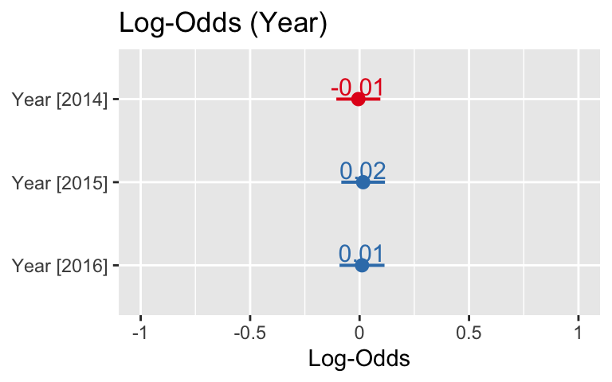

Figure 5: The log-odds for Obesity by Year

Then we fit the logistic regression model for the explanatory variables, age group, sex, and employment,

$$\mbox{ln}(\frac{p}{1-p}) = \alpha + \beta_{\mbox{AgeGroup}} \cdot \mathbb{I}_{\mbox{AgeGroup}}(x) + \beta_{\mbox{Sex}} \cdot \mathbb{I}_{\mbox{Sex}}(x) + \beta_{\mbox{Employment}} \cdot \mathbb{I}_{\mbox{Employment}}(x)$$

where

- $p$ is the probability of obesity
- $1-p$ is the probability of not obesity
- $\alpha$ is the intercept of the regression line for the baseline AgeGroup (16-24), Sex (Female), Employment (Doing something else)
- $\beta_{\mbox{AgeGroup}}$ the additional term added to $\alpha$ to get the intercept of the regression line for the specified AgeGroup
- $\beta_{\mbox{Sex}}$ the additional term added to $\alpha$ to get the intercept of the regression line for the specified Sex
- $\beta_{\mbox{Employment}}$ the additional term added to $\alpha$ to get the intercept of the regression line for the specified Employment
- $\mathbb{I}_{\mbox{AgeGroup}}(x)$ is an indicator function indicating the chosen AgeGroup.
- $\mathbb{I}_{\mbox{Sex}}(x)$ is an indicator function indicating the chosen Sex.
- $\mathbb{I}_{\mbox{Employment}}(x)$ is an indicator function indicating the chosen Employment.

Table 2: Coefficients from the fitted logistic regression model with all explanatory variables

| term | estimate | std.error | p.value |
| --- | --- | --- | --- |
| (Intercept) | −1.5249 | 0.1590 | 0.0000 |
| AgeGroup25-34 | 0.4216 | 0.1049 | 0.0001 |
| AgeGroup35-44 | 0.6303 | 0.1029 | 0.0000 |
| AgeGroup45-54 | 0.8157 | 0.1012 | 0.0000 |
| AgeGroup55-64 | 0.9087 | 0.1034 | 0.0000 |
| AgeGroup65-74 | 1.0140 | 0.1212 | 0.0000 |
| AgeGroup75+ | 0.6638 | 0.1324 | 0.0000 |
| SexMale | −0.1001 | 0.0379 | 0.0083 |
| EmploymentIn full-time education | −0.3010 | 0.1741 | 0.0840 |
| EmploymentIn paid employment, self-employed or on gov't training | −0.0330 | 0.1339 | 0.8054 |
| EmploymentLooking after home/family | 0.4104 | 0.1650 | 0.0129 |
| EmploymentLooking for/intending to look for paid work | 0.2626 | 0.1658 | 0.1132 |
| EmploymentPerm unable to work | 0.4734 | 0.1547 | 0.0022 |
| EmploymentRetired | 0.0198 | 0.1470 | 0.8929 |

It’s worth noting that some employment statuses have p-values above 0.05, such as Retired, then it shows that there is not statistically significant at the 5% level. Similarly, we can also plot log-odds Figure 6 to graphically display the 95% confidence interval of the fitted model.

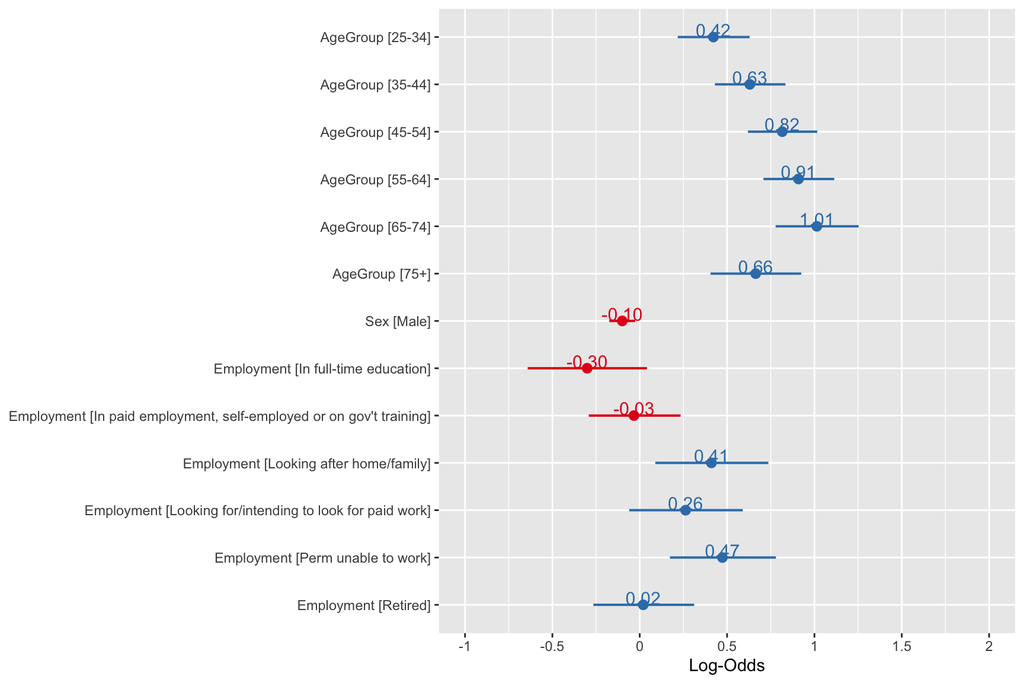

Figure 6: Log-Odds for age group, sex, employment

# 4 Conclusion